```python
%pip install nbformat>=4.2.0
```

[output not shown]

```python
import pandas as pd
import numpy as np
import matplotlib.pyplot as plt
import seaborn as sns
import plotly.express as px
import plotly.io as pio

# Görsel ayarlar ve Plotly'nin internette düzgün görünmesi için gereken ayar
sns.set_style("whitegrid")
plt.rcParams["figure.figsize"] = (10,5)
pio.renderers.default = "notebook"

# Bilgisayara dosya indirmeden, internetteki gerçek dünya e-ticaret verisini doğrudan çekiyoruz
url = "https://raw.githubusercontent.com/erkansirin78/datasets/master/Churn_Modelling.csv"
df = pd.read_csv(url)

# Hoca en az 300 satır istemişti, bu gerçek veri tam 10.000 satır ve 14 sütun!
# Bilgisayarın kasmasın diye rastgele 1000 satırlık tertemiz bir örnek alıyoruz
df = df.sample(n=1000, random_state=42).reset_index(drop=True)

# İlk 5 satırı ekranda görelim
df.head()
```

|  | RowNumber | CustomerId | Surname | CreditScore | Geography | Gender | Age | Tenure | Balance | NumOfProducts | HasCrCard | IsActiveMember | EstimatedSalary | Exited |
| --- | --- | --- | --- | --- | --- | --- | --- | --- | --- | --- | --- | --- | --- | --- |
| 0 | 6253 | 15687492 | Anderson | 596 | Germany | Male | 32 | 3 | 96709.07 | 2 | 0 | 0 | 41788.37 | 0 |
| 1 | 4685 | 15736963 | Herring | 623 | France | Male | 43 | 1 | 0.00 | 2 | 1 | 1 | 146379.30 | 0 |
| 2 | 1732 | 15721730 | Amechi | 601 | Spain | Female | 44 | 4 | 0.00 | 2 | 1 | 0 | 58561.31 | 0 |
| 3 | 4743 | 15762134 | Liang | 506 | Germany | Male | 59 | 8 | 119152.10 | 2 | 1 | 1 | 170679.74 | 0 |
| 4 | 4522 | 15648898 | Chuang | 560 | Spain | Female | 27 | 7 | 124995.98 | 1 | 1 | 1 | 114669.79 | 0 |

```python
# 1. Genel Sayısal Özet (Müşterilerin kredi skoru, yaşları, bakiyeleri ne durumda?)
print("--- 1. Sayısal Sütunların Genel Özeti ---")
display(df[['CreditScore', 'Age', 'Balance', 'EstimatedSalary']].describe())

# 2. Müşterilerin Ülkelere Göre Dağılımı (Kategorik Frekans Dağılımı)
print("\n--- 2. Müşterilerin Yaşadığı Ülkeler (Frekans) ---")
display(df['Geography'].value_counts())

# 3. Ülkelere ve Cinsiyete Göre Ortalama Bakiye Durumu (Gruplandırılmış İstatistik)
print("\n--- 3. Ülke ve Cinsiyete Göre Ortalama Bakiye ---")
display(df.groupby(['Geography', 'Gender'])['Balance'].mean().reset_index())

# 4. Sayısal Değişkenlerin Birbiriyle İlişkisi (Korelasyon Matrisi)
print("\n--- 4. Değişkenlerin Korelasyon Matrisi ---")
display(df[['CreditScore', 'Age', 'Balance', 'EstimatedSalary']].corr())
```

```
--- 1. Sayısal Sütunların Genel Özeti ---
```

|  | CreditScore | Age | Balance | EstimatedSalary |
| --- | --- | --- | --- | --- |
| count | 1000.000000 | 1000.000000 | 1000.000000 | 1000.000000 |
| mean | 644.420000 | 38.850000 | 80675.944630 | 102168.880020 |
| std | 98.893557 | 10.233975 | 61796.241114 | 57199.831235 |
| min | 350.000000 | 18.000000 | 0.000000 | 142.810000 |
| 25% | 577.000000 | 32.000000 | 0.000000 | 54313.997500 |
| 50% | 647.000000 | 38.000000 | 101648.475000 | 102206.795000 |
| 75% | 710.000000 | 44.000000 | 129442.252500 | 150729.630000 |
| max | 850.000000 | 88.000000 | 209490.210000 | 199992.480000 |

```
--- 2. Müşterilerin Yaşadığı Ülkeler (Frekans) ---
```

```
Geography
France     505
Germany    266
Spain      229
Name: count, dtype: int64
```

```
--- 3. Ülke ve Cinsiyete Göre Ortalama Bakiye ---
```

|  | Geography | Gender | Balance |
| --- | --- | --- | --- |
| 0 | France | Female | 58002.670330 |
| 1 | France | Male | 72085.532594 |
| 2 | Germany | Female | 119196.684000 |
| 3 | Germany | Male | 114699.023058 |
| 4 | Spain | Female | 71645.340673 |
| 5 | Spain | Male | 69160.808560 |

```
--- 4. Değişkenlerin Korelasyon Matrisi ---
```

|  | CreditScore | Age | Balance | EstimatedSalary |
| --- | --- | --- | --- | --- |
| CreditScore | 1.000000 | -0.021312 | 0.028471 | 0.018991 |
| Age | -0.021312 | 1.000000 | 0.016347 | -0.020027 |
| Balance | 0.028471 | 0.016347 | 1.000000 | -0.014400 |
| EstimatedSalary | 0.018991 | -0.020027 | -0.014400 | 1.000000 |

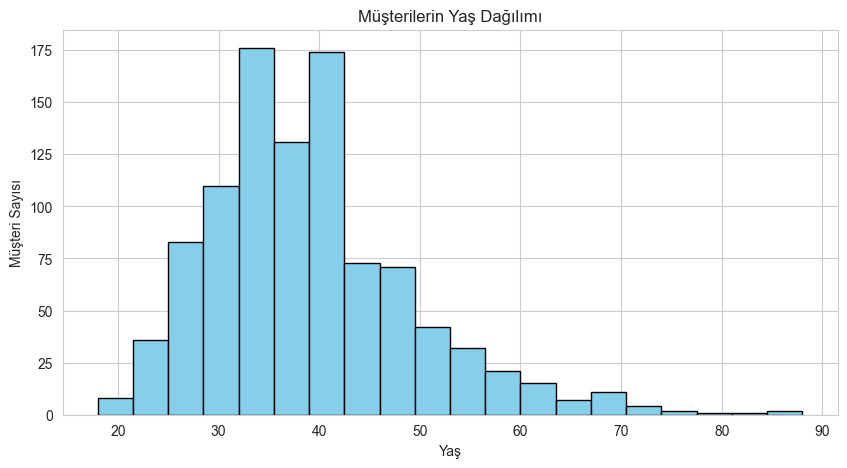

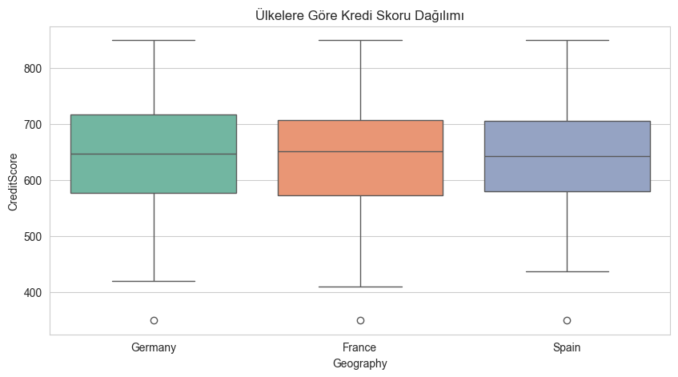

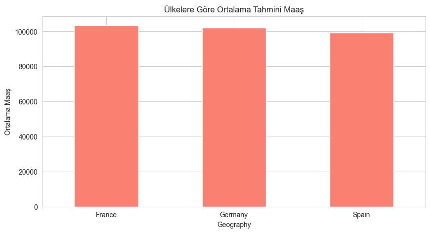

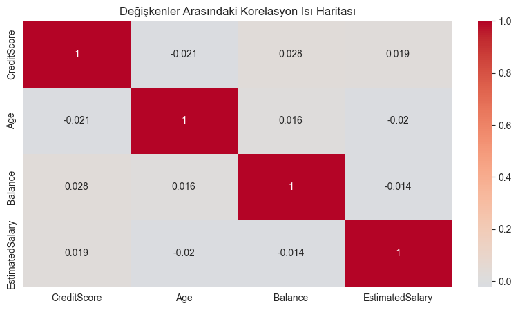

[output not shown]

[interactive chart not shown]

```python
# GRAFİK 1: Histogram (Yaş Dağılımı - Matplotlib)
fig, ax = plt.subplots()
df['Age'].hist(bins=20, ax=ax, color='skyblue', edgecolor='black')
ax.set_title("Müşterilerin Yaş Dağılımı")
ax.set_xlabel("Yaş")
ax.set_ylabel("Müşteri Sayısı")
plt.show()

# GRAFİK 2: Boxplot (Kredi Skorları ve Ülkeler - Seaborn)
sns.boxplot(data=df, x='Geography', y='CreditScore', palette='Set2')
plt.title("Ülkelere Göre Kredi Skoru Dağılımı")
plt.show()

# GRAFİK 3: Çubuk Grafik (Ülkelere Göre Ortalama Tahmini Maaş - Pandas)
df.groupby('Geography')['EstimatedSalary'].mean().plot(kind='bar', color='salmon', rot=0)
plt.title("Ülkelere Göre Ortalama Tahmini Maaş")
plt.ylabel("Ortalama Maaş")
plt.show()

# GRAFİK 4: Isı Haritası (Korelasyon Matrisi Görselleştirmesi - Seaborn)
sns.heatmap(df[['CreditScore', 'Age', 'Balance', 'EstimatedSalary']].corr(), annot=True, cmap='coolwarm', center=0)
plt.title("Değişkenler Arasındaki Korelasyon Isı Haritası")
plt.show()

# GRAFİK 5 (BONUS): İnteraktif Saçılım Grafiği (Yaş vs Bakiye - Plotly Express)
fig_plotly = px.scatter(df, x="Age", y="Balance", color="Geography", size="CreditScore",
                        title="Yaş ve Bakiye İlişkisi (Ülke Bazlı ve Kredi Skoru Boyutlu)")

# .show() yerine doğrudan ismini yazarak VS Code'un kendi tarayıcısını tetikliyoruz
fig_plotly
```

### Grafiklerin Detaylı Analizi ve Yorumlar

- Grafik 1: Müşterilerin Yaş Dağılımı (Histogram):** Banka müşteri portföyünün yaş dağılımı incelendiğinde, verinin 30 ile 45 yaş arasında belirgin bir tepe noktası oluşturduğu görülmektedir. Bu durum, bankanın ana hedef kitlesinin ve aktif kullanıcılarının ekonomik olarak üretken olan orta yaş grubunda yoğunlaştığını, genç ve ileri yaş segmentinin ise daha düşük paya sahip olduğunu göstermektedir.
- Grafik 2: Ülkelere Göre Kredi Skoru Dağılımı (Boxplot):** Fransa, Almanya ve İspanya'daki müşterilerin kredi skorları kutu grafiği ile karşılaştırılmıştır. Üç ülkenin de medyan (orta nokta) çizgilerinin ve kutu sınırlarının neredeyse tamamen aynı hizada olması, coğrafi konumdan bağımsız olarak bankanın tüm ülkelerde benzer finansal güvenilirliğe ve kredi kalitesine sahip bir müşteri profiline hizmet verdiğini kanıtlamaktadır.
- Grafik 3: Ülkelere Göre Ortalama Tahmini Maaş (Bar Plot):** Müşterilerin beyan ettiği yıllık tahmini maaşların ülkelere göre ortalaması alındığında, sütun boylarının birbirine oldukça denk olduğu (yaklaşık 100.000 birim) gözlemlenmiştir. Bu bulgu, bankanın her üç ülkede de benzer gelir düzeyine sahip, homojen bir ekonomik segmente hitap ettiğini ortaya koymaktadır.
- Grafik 4: Değişkenler Arasındaki İlişki (Korelasyon Isı Haritası):** Sayısal değişkenlerin birbiriyle olan ilişkisini gösteren korelasyon katsayılarının sıfıra çok yakın olması, değişkenler arasında güçlü bir doğrusal bağ olmadığını göstermektedir. Yani bir müşterinin yaşının ilerlemiş olması veya tahmini maaşının yüksek olması, bankadaki bakiyesinin ya da kredi skorunun mutlaka yüksek olacağı anlamına gelmemektedir; finansal davranışlar kişisel bazda bağımsız şekillenmektedir.
- Grafik 5: Yaş ve Bakiye İlişkisi (Plotly İnteraktif Grafik):** Etkileşimli saçılım grafiğinde, müşterilerin yaşları ile bankada tuttukları bakiye miktarı katmanlı olarak incelenmiştir. Genel bakiye dağılımının yaş gruplarına göre geniş bir yelpazeye yayıldığı görülmekle birlikte, Plotly'nin dinamik hover (üzerine gelme) özellikleri sayesinde belirli yaş gruplarındaki kırılımlar ve ülke bazlı finansal birikim farkları raporun web sürümünde interaktif olarak izlenebilmektedir.

BULGULAR

1. Müşteri Yoğunluğu Orta Yaş Grubundadır: Yaş dağılımı histogramı incelendiğinde, bankanın ana müşteri kitlesinin 30-45 yaş aralığındaki aktif çalışan nüfusta yoğunlaştığı görülmüştür. Genç ve yaşlı kitlelerin payı daha düşüktür.
2. En Büyük Pazar Fransa'dır: Kategorik dağılım analizine göre, bankanın en fazla müşteriye sahip olduğu ülke açık ara Fransa olarak öne çıkmaktadır. Almanya ve İspanya ise benzer müşteri sayılarıyla onu takip etmektedir.
3. Finansal Değişkenler Birbirinden Bağımsızdır: Korelasyon ısı haritasından (Heatmap) elde edilen verilere göre, müşterilerin kredi skorları, yaşları ve bankadaki bakiyeleri arasında güçlü bir ilişki bulunamamıştır (korelasyon sıfıra yakındır). Bu durum, ileri yaşın veya yüksek maaşın her zaman yüksek bakiye anlamına gelmediğini göstermektedir.